# Neural Representations of Multilayer Social Network Information Analysis: Univariate Analyses

Ovidia Stanoi

4/12/2025

In this script, we ran 3 regression models. The first model (Model 1) estimates participants’ neural responses to peers’ faces in our 9 ROIs as a function of how much more status peers have relative to them in a **dual space that includes information from both the popularity and leadership dimension** (`dual_relative_status`). The second model (Model 2) estimates participants’ neural responses to peers’ faces in the 9 ROIs as a function of how much more **popularity status** peers have relative to them. In practice, we estimated participants’ mean neural response to each peer face as a function of that peer’s popularity status, while holding constant the perceiver’s own popularity status. By including the participants’ own status in the model, the parameter of the relationship between the target’s status and neural activity provides an estimate of participants’ mean response to the targets’ status relative to their own. The third model (Model 3) estimates participants’ neural responses to peers’ faces in the 9 ROIs as a function of how much more **leadership status** peers have relative to them. The same method was used as in Model 2. To account for multiple comparisons, all models are run in a multilevel framework with random slopes per ROI nested within brain systems (valuation, social cognition, relational binding). We also included random intercepts for perceivers and targets, nested within groups. **No** control variables were included in these models.

Clear global environment.

```r
remove(list=ls())
```

Open packages.

```r
library("tidyverse")
library("corrplot")
library("reshape")
library("rstanarm")
library("bmlm")
library("bayestestR")
library("flextable")
library("officer")
library("brms")
library("tidybayes")
```

Set up ggplot theme.

```r
theme_set(theme_bw() +
            theme(plot.title = element_text(size=14, hjust = .5),
                  axis.text=element_text(size=12),
                  axis.title=element_text(size=13),
                  # plot.title = element_text(size=20, hjust = .5), # use this for .pdf version of figures instead of .html
                  # axis.text=element_text(size=20),  # use this for .pdf version of figures instead of .html
                  # axis.title=element_text(size=22), # use this for .pdf version of figures instead of .html
                  axis.line = element_line(colour = "gray"),
                  panel.border = element_rect(colour = "gray"),
                  panel.grid.minor = element_blank(),
                  axis.text.x = element_text(angle = 15, hjust = 1),
                  panel.background = element_rect(colour = "gray", linewidth = .8),
                  legend.position = "none"))
```

Set up the file directory.

```r
path <- "~/Dropbox/Psychology_Projects/MURI Faces 2D"
```

Read the dataset including each participant’s ROI-level neural responses to different faces and status information.

```r
d <- read.csv(sprintf("%s/Data/univariate_dataset.csv", path)) %>%
  select(groupID, pid, face, roi, neural_response, dual_relative_status_cw,
         face_like_strength_in_cw, face_leader_strength_in_cw,
         pid_like_strength_in_cw, pid_leader_strength_in_cw)
d$brain_system <- ifelse(d$roi %in% c("HO_amygdala", "Kable_VS", "vmPFC"), "valuation",
                         ifelse(d$roi %in% c("ERC", "r_HPC", "l_HPC"), "relational_binding",
                                ifelse(d$roi %in% c("Saxe_dmPFC", "l_TPJ", "r_TPJ"), "social_cognition", NA)))
```

Check the format of the dataset.

```r
head(d)
```

|  | groupID | pid | face | roi | neural_response | dual_relative_status_cw | face_like_strength_in_cw | face_leader_strength_in_cw | pid_like_strength_in_cw | pid_leader_strength_in_cw | brain_system |
| --- | --- | --- | --- | --- | --- | --- | --- | --- | --- | --- | --- |
| 1 | g10p | muri369 | muri368 | ERC | 0.07067577 | 0.07010922 | 0.07465642 | 0.03132934 | -0.3495278 | -0.3592026 | relational_binding |
| 2 | g10p | muri369 | muri368 | l_HPC | 1.10138371 | 0.07010922 | 0.07465642 | 0.03132934 | -0.3495278 | -0.3592026 | relational_binding |
| 3 | g10p | muri369 | muri368 | r_HPC | -0.87328208 | 0.07010922 | 0.07465642 | 0.03132934 | -0.3495278 | -0.3592026 | relational_binding |
| 4 | g10p | muri369 | muri368 | l_TPJ | 6.42793539 | 0.07010922 | 0.07465642 | 0.03132934 | -0.3495278 | -0.3592026 | social_cognition |
| 5 | g10p | muri369 | muri368 | r_TPJ | 0.07152718 | 0.07010922 | 0.07465642 | 0.03132934 | -0.3495278 | -0.3592026 | social_cognition |
| 6 | g10p | muri369 | muri368 | vmPFC | -1.57933816 | 0.07010922 | 0.07465642 | 0.03132934 | -0.3495278 | -0.3592026 | valuation |

# 1 Model 1 (Relative Dual Status)

Run regression model for relative dual status.

```r
# options(mc.cores = parallel::detectCores())
# m <- brm(neural_response ~ dual_relative_status_cw +
#                   (1 | groupID:pid) + (1 | groupID:face) +
#                   (dual_relative_status_cw | brain_system:roi),
#             data = d,
#             control = list(adapt_delta = 0.99),
#             seed = 123)
# save(m, file = sprintf("%s/Model Results/Univariate_Model1.RData", path))
```

Obtain ROI-level varying betas for the main effect of targets’ **relative dual status measures** on the perceivers’ ROI-level neural responses.

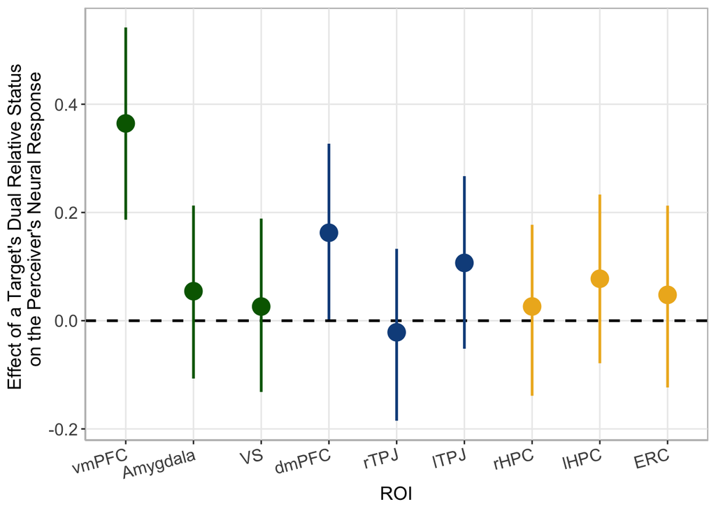

```r
# Load model results
load(sprintf("%s/Model Results/Univariate_Model1.RData", path))

# Extract posterior draws
roi_draws <- m %>%
  spread_draws(b_Intercept, b_dual_relative_status_cw,
               `r_brain_system:roi`[roi, term]) %>%
  filter(term == "dual_relative_status_cw")  %>%
  mutate(beta =  b_dual_relative_status_cw + `r_brain_system:roi`) %>%
  mutate(roi = dplyr::recode(roi,
                             "social_cognition_Saxe_dmPFC" = "dmPFC",
                             "valuation_HO_amygdala" = "Amygdala",
                             "relational_binding_r_HPC" = "rHPC",
                             "social_cognition_r_TPJ" = "rTPJ",
                             "valuation_Kable_VS" = "VS",
                             "relational_binding_ERC" = "ERC",
                             "relational_binding_l_HPC" = "lHPC",
                             "social_cognition_l_TPJ" = "lTPJ",
                             "valuation_vmPFC" = "vmPFC"),
         roi = factor(roi, levels = c("vmPFC", "Amygdala", "VS",
                                          "dmPFC", "rTPJ", "lTPJ",
                                          "rHPC", "lHPC", "ERC")),
         roi_type = ifelse(roi %in% c("vmPFC", "Amygdala", "VS"), "valuation",
                        ifelse(roi %in% c("dmPFC", "rTPJ", "lTPJ"), "social_cognition",
                               "relational_binding"))) %>%
  select(.draw, roi, roi_type, term, beta)

# Summarize estimates per ROI
b_df <- roi_draws %>%
  group_by(roi, roi_type, term) %>%
  summarise(beta_2d = median(beta),
            sd = sd(beta),
            low_ci = quantile(beta, 0.025),
            upp_ci = quantile(beta, 0.975))

# Plot betas' posterior mean and 95% credible interval
ggplot(data = b_df[b_df$term == "dual_relative_status_cw",],
       aes(x = roi,
           y = beta_2d)) +
  geom_hline(yintercept = 0,
             linewidth = 0.9, linetype = 2) +
  geom_pointrange(aes(ymin = low_ci,
                      ymax = upp_ci, color = roi_type),
                   size = 1.2, linewidth = .9) +
                   # size = 2, linewidth = 2.5) +
  scale_color_manual(values = c("goldenrod2", "dodgerblue4", "darkgreen")) +
  labs(x = "ROI", y = "Effect of a Target's Dual Relative Status
  on the Perceiver's Neural Response")
```

Check results.

```r
# Arrange data
b_df_table <- b_df %>%
  filter(term == "dual_relative_status_cw") %>%
  ungroup() %>%
  mutate(across(where(is.numeric), ~ round(.x, 2)),
         CI_95 = paste0("[", round(low_ci, 2), ", ", round(upp_ci, 2), "]")) %>%
  select(-any_of(c("low_ci", "upp_ci", "roi_type", "term"))) %>%
  arrange(roi)

# Create table of results
b_df_table <- flextable(b_df_table) %>%
  set_header_labels(roi = "ROI",
    beta_2d = "Beta Estimate",
    sd = "SE",
    CI_95 = "95% CI") %>%
  autofit() %>%
  theme_booktabs()

# Save to Word document
doc <- read_docx() %>%
  body_add_par("Table: Univariate Results: Effect of Target's Relative Dual Status on ROI Neural Activity",
               style = "heading 2") %>%
  body_add_flextable(b_df_table)

print(doc, target = sprintf("%s/Tables/TableS13_Univariate_Model1_Dual_Status_Betas.docx", path))

b_df_table
```

| ROI | Beta Estimate | SE | 95% CI |
| --- | --- | --- | --- |
| vmPFC | 0.36 | 0.09 | [0.19, 0.54] |
| Amygdala | 0.05 | 0.08 | [-0.11, 0.21] |
| VS | 0.03 | 0.08 | [-0.13, 0.19] |
| dmPFC | 0.16 | 0.08 | [0, 0.33] |
| rTPJ | -0.02 | 0.08 | [-0.18, 0.13] |
| lTPJ | 0.11 | 0.08 | [-0.05, 0.27] |
| rHPC | 0.03 | 0.08 | [-0.14, 0.18] |
| lHPC | 0.08 | 0.08 | [-0.08, 0.23] |
| ERC | 0.05 | 0.08 | [-0.12, 0.21] |

What percentage of the distribution is higher than zero for the vmPFC and dmPFC main effects?

```r
# vmPFC
round(length(which(roi_draws$beta[roi_draws$roi == "vmPFC"]>0))/4000*100,1)
```

```
## [1] 100
```

```r
# dmPFC
round(length(which(roi_draws$beta[roi_draws$roi == "dmPFC"]>0))/4000*100,1)
```

```
## [1] 97.8
```

Check convergence (R-hat, bulk & tail ESS).

```r
summary(m)
```

```
##  Family: gaussian
##   Links: mu = identity; sigma = identity
## Formula: neural_response ~ dual_relative_status_cw + (1 | groupID:pid) + (1 | groupID:face) + (dual_relative_status_cw | brain_system:roi)
##    Data: d (Number of observations: 19822)
##   Draws: 4 chains, each with iter = 2000; warmup = 1000; thin = 1;
##          total post-warmup draws = 4000
##
## Group-Level Effects:
## ~brain_system:roi (Number of levels: 9)
##                                        Estimate Est.Error l-95% CI u-95% CI
## sd(Intercept)                              0.86      0.28     0.50     1.55
## sd(dual_relative_status_cw)                0.17      0.07     0.07     0.34
## cor(Intercept,dual_relative_status_cw)     0.33      0.35    -0.44     0.86
##                                        Rhat Bulk_ESS Tail_ESS
## sd(Intercept)                          1.00      890     1155
## sd(dual_relative_status_cw)            1.00     1238     1905
## cor(Intercept,dual_relative_status_cw) 1.00     1781     2087
##
## ~groupID:face (Number of levels: 233)
##               Estimate Est.Error l-95% CI u-95% CI Rhat Bulk_ESS Tail_ESS
## sd(Intercept)     0.78      0.05     0.67     0.89 1.00      972     1778
##
## ~groupID:pid (Number of levels: 94)
##               Estimate Est.Error l-95% CI u-95% CI Rhat Bulk_ESS Tail_ESS
## sd(Intercept)     0.73      0.06     0.63     0.86 1.00      799     1266
##
## Population-Level Effects:
##                         Estimate Est.Error l-95% CI u-95% CI Rhat Bulk_ESS
## Intercept                   0.72      0.33     0.10     1.35 1.01      452
## dual_relative_status_cw     0.09      0.08    -0.07     0.25 1.00     1254
##                         Tail_ESS
## Intercept                   1007
## dual_relative_status_cw     1548
##
## Family Specific Parameters:
##       Estimate Est.Error l-95% CI u-95% CI Rhat Bulk_ESS Tail_ESS
## sigma     3.46      0.02     3.43     3.50 1.00     5817     3005
##
## Draws were sampled using sampling(NUTS). For each parameter, Bulk_ESS
## and Tail_ESS are effective sample size measures, and Rhat is the potential
## scale reduction factor on split chains (at convergence, Rhat = 1).
```

```r
draws <- as_draws_df(m)
summarise_draws(draws, rhat, "ess_bulk", "ess_tail") %>%
  filter(grepl("brain_system:roi", variable)) %>%
  mutate(across(where(is.numeric), ~ round(.x, 4)))
```

| variable | rhat | ess_bulk | ess_tail |
| --- | --- | --- | --- |
| sd_brain_system:roi__Intercept | 1.0049 | 890.4577 | 1155.124 |
| sd_brain_system:roi__dual_relative_status_cw | 1.0012 | 1238.1164 | 1904.638 |
| cor_brain_system:roi__Intercept__dual_relative_status_cw | 1.0035 | 1780.8301 | 2087.004 |
| r_brain_system:roi[relational_binding_ERC,Intercept] | 1.0106 | 514.9637 | 1125.860 |
| r_brain_system:roi[relational_binding_l_HPC,Intercept] | 1.0095 | 600.2412 | 1190.062 |
| r_brain_system:roi[relational_binding_r_HPC,Intercept] | 1.0094 | 570.0840 | 1132.634 |
| r_brain_system:roi[social_cognition_l_TPJ,Intercept] | 1.0097 | 560.4322 | 1067.089 |
| r_brain_system:roi[social_cognition_r_TPJ,Intercept] | 1.0093 | 585.7277 | 1182.854 |
| r_brain_system:roi[social_cognition_Saxe_dmPFC,Intercept] | 1.0086 | 573.6849 | 1140.526 |
| r_brain_system:roi[valuation_HO_amygdala,Intercept] | 1.0099 | 603.0108 | 1158.880 |

[output cut: 11 more lines]

# 2 Model 2 (Relative Popularity Status)

Run regression model for relative popularity status alone.

```r
# options(mc.cores = parallel::detectCores())
# m2 <- brm(neural_response ~ face_like_strength_in_cw + pid_like_strength_in_cw +
#                    (1 | groupID:pid) + (1 | groupID:face) +
#                    (face_like_strength_in_cw | brain_system:roi),
#             data = d,
#             control = list(adapt_delta = 0.99),
#             seed = 123)
# save(m2, file = sprintf("%s/Model Results/Univariate_Model2.RData", path))
```

Obtain ROI-level varying betas for the main effect of a **target’s popularity status measure** on the perceiver’s ROI-level neural responses. Since we are controlling in the model for the perceiver’s popularity status, this is in effect a measure of the target’s **relative** popularity status.

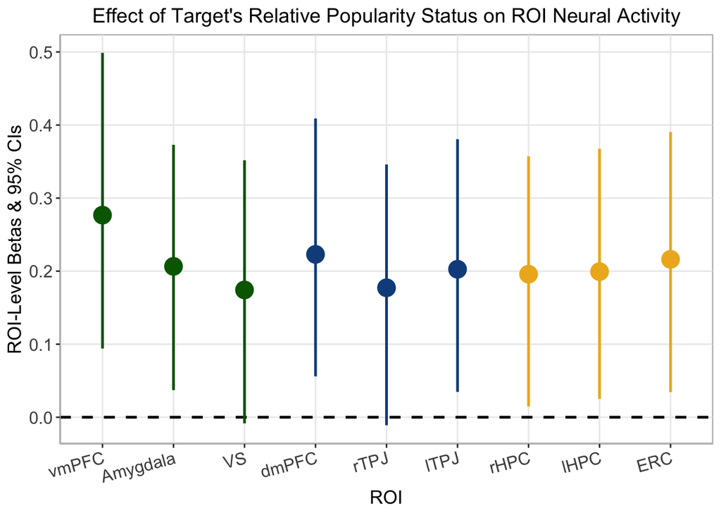

```r
# Load model results
load(sprintf("%s/Model Results/Univariate_Model2.RData", path))

# Extract posterior draws
roi_draws <- m2 %>%
  spread_draws(b_face_like_strength_in_cw,
               `r_brain_system:roi`[roi, term]) %>%
  filter(term == "face_like_strength_in_cw") %>%
  mutate(beta = b_face_like_strength_in_cw + `r_brain_system:roi`) %>%
  mutate(roi = dplyr::recode(roi,
                             "social_cognition_Saxe_dmPFC" = "dmPFC",
                             "valuation_HO_amygdala" = "Amygdala",
                             "relational_binding_r_HPC" = "rHPC",
                             "social_cognition_r_TPJ" = "rTPJ",
                             "valuation_Kable_VS" = "VS",
                             "relational_binding_ERC" = "ERC",
                             "relational_binding_l_HPC" = "lHPC",
                             "social_cognition_l_TPJ" = "lTPJ",
                             "valuation_vmPFC" = "vmPFC"),
         roi = factor(roi, levels = c("vmPFC", "Amygdala", "VS",
                                          "dmPFC", "rTPJ", "lTPJ",
                                          "rHPC", "lHPC", "ERC")),
         roi_type = ifelse(roi %in% c("vmPFC", "Amygdala", "VS"), "valuation",
                        ifelse(roi %in% c("dmPFC", "rTPJ", "lTPJ"), "social_cognition",
                               "relational_binding"))) %>%
  select(.draw, roi, roi_type, beta)

# Summarize estimates per ROI
b_df_like <- roi_draws %>%
  group_by(roi, roi_type, term) %>%
  summarise(beta_like = median(beta),
            sd = sd(beta),
            low_ci = quantile(beta, 0.025),
            upp_ci = quantile(beta, 0.975))

# Plot betas' posterior means and 95% credible intervals
ggplot(data = b_df_like,
       aes(x = roi,
           y = beta_like)) +
  geom_hline(yintercept = 0,
             linewidth = 0.9, linetype = 2) +
  geom_pointrange(aes(ymin = low_ci,
                      ymax = upp_ci, color = roi_type),
                  size = 1.2, linewidth = .9) +
  scale_color_manual(values = c("goldenrod2", "dodgerblue4", "darkgreen")) +
  labs(x = "ROI", y = "ROI-Level Betas & 95% CIs",
       title = "Effect of Target's Relative Popularity Status on ROI Neural Activity")
```

Check results.

```r
# Arrange data
b_df_table <- b_df_like %>%
  ungroup() %>%
  mutate(across(where(is.numeric), ~ round(.x, 2)),
         CI_95 = paste0("[", round(low_ci, 2), ", ", round(upp_ci, 2), "]")) %>%
  select(-any_of(c("low_ci", "upp_ci", "roi_type", "term"))) %>%
  arrange(roi)

# Create table of results
b_df_table <- flextable(b_df_table) %>%
  set_header_labels(roi = "ROI",
    beta_like = "Beta Estimate",
    sd = "SE",
    CI_95 = "95% CI") %>%
  autofit() %>%
  theme_booktabs()

# Save to Word document
doc <- read_docx() %>%
  body_add_par("Table: Univariate Results: Effect of Target's Relative Popularity Status on ROI Neural Activity",
               style = "heading 2") %>%
  body_add_flextable(b_df_table)

print(doc, target = sprintf("%s/Tables/TableS11_Univariate_Model2_Popularity_Betas.docx", path))

b_df_table
```

| ROI | Beta Estimate | SE | 95% CI |
| --- | --- | --- | --- |
| vmPFC | 0.28 | 0.10 | [0.09, 0.5] |
| Amygdala | 0.21 | 0.09 | [0.04, 0.37] |
| VS | 0.17 | 0.09 | [-0.01, 0.35] |
| dmPFC | 0.22 | 0.09 | [0.06, 0.41] |
| rTPJ | 0.18 | 0.09 | [-0.01, 0.35] |
| lTPJ | 0.20 | 0.09 | [0.03, 0.38] |
| rHPC | 0.20 | 0.09 | [0.01, 0.36] |
| lHPC | 0.20 | 0.09 | [0.03, 0.37] |
| ERC | 0.22 | 0.09 | [0.03, 0.39] |

What percentage of the distribution is higher than zero for different ROI main effects?

```r
# vmPFC
round(length(which(roi_draws$beta[roi_draws$roi == "vmPFC"]>0))/4000*100,1)
```

```
## [1] 100
```

```r
# bilateral amygdala
round(length(which(roi_draws$beta[roi_draws$roi == "Amygdala"]>0))/4000*100,1)
```

```
## [1] 99.2
```

```r
# dmPFC
round(length(which(roi_draws$beta[roi_draws$roi == "dmPFC"]>0))/4000*100,1)
```

```
## [1] 99.5
```

```r
# lTPJ
round(length(which(roi_draws$beta[roi_draws$roi == "lTPJ"]>0))/4000*100,1)
```

```
## [1] 99.1
```

```r
# rHPC
round(length(which(roi_draws$beta[roi_draws$roi == "rHPC"]>0))/4000*100,1)
```

```
## [1] 98.1
```

```r
# lHPC
round(length(which(roi_draws$beta[roi_draws$roi == "lHPC"]>0))/4000*100,1)
```

```
## [1] 98.8
```

```r
# ERC
round(length(which(roi_draws$beta[roi_draws$roi == "ERC"]>0))/4000*100,1)
```

```
## [1] 99.1
```

Check convergence (R-hat, bulk & tail ESS).

```r
summary(m2)
```

```
##  Family: gaussian
##   Links: mu = identity; sigma = identity
## Formula: neural_response ~ face_like_strength_in_cw + pid_like_strength_in_cw + (1 | groupID:pid) + (1 | groupID:face) + (face_like_strength_in_cw | brain_system:roi)
##    Data: d (Number of observations: 19822)
##   Draws: 4 chains, each with iter = 2000; warmup = 1000; thin = 1;
##          total post-warmup draws = 4000
##
## Group-Level Effects:
## ~brain_system:roi (Number of levels: 9)
##                                         Estimate Est.Error l-95% CI u-95% CI
## sd(Intercept)                               0.83      0.25     0.49     1.46
## sd(face_like_strength_in_cw)                0.07      0.05     0.00     0.19
## cor(Intercept,face_like_strength_in_cw)     0.30      0.50    -0.81     0.97
##                                         Rhat Bulk_ESS Tail_ESS
## sd(Intercept)                           1.00     1009     1863
## sd(face_like_strength_in_cw)            1.00     1523     1788
## cor(Intercept,face_like_strength_in_cw) 1.00     4047     2527
##
## ~groupID:face (Number of levels: 233)
##               Estimate Est.Error l-95% CI u-95% CI Rhat Bulk_ESS Tail_ESS
## sd(Intercept)     0.78      0.05     0.68     0.89 1.00     1273     2195
##
## ~groupID:pid (Number of levels: 94)
##               Estimate Est.Error l-95% CI u-95% CI Rhat Bulk_ESS Tail_ESS
## sd(Intercept)     0.73      0.06     0.62     0.86 1.00      865     1982
##
## Population-Level Effects:
##                          Estimate Est.Error l-95% CI u-95% CI Rhat Bulk_ESS
## Intercept                    0.72      0.29     0.14     1.32 1.00      690
## face_like_strength_in_cw     0.21      0.08     0.06     0.36 1.00     1255
## pid_like_strength_in_cw      0.11      0.12    -0.13     0.36 1.01      697
##                          Tail_ESS
## Intercept                    1149
## face_like_strength_in_cw     1966
## pid_like_strength_in_cw      1411
##
## Family Specific Parameters:
##       Estimate Est.Error l-95% CI u-95% CI Rhat Bulk_ESS Tail_ESS
## sigma     3.46      0.02     3.43     3.50 1.00     8476     3237
##
## Draws were sampled using sampling(NUTS). For each parameter, Bulk_ESS
## and Tail_ESS are effective sample size measures, and Rhat is the potential
## scale reduction factor on split chains (at convergence, Rhat = 1).
```

```r
draws <- as_draws_df(m2)
summarise_draws(draws, rhat, "ess_bulk", "ess_tail") %>%
  filter(grepl("brain_system:roi", variable)) %>%
  mutate(across(where(is.numeric), ~ round(.x, 4)))
```

| variable | rhat | ess_bulk | ess_tail |
| --- | --- | --- | --- |
| sd_brain_system:roi__Intercept | 1.0034 | 1009.0147 | 1862.817 |
| sd_brain_system:roi__face_like_strength_in_cw | 1.0022 | 1523.1473 | 1787.872 |
| cor_brain_system:roi__Intercept__face_like_strength_in_cw | 1.0031 | 4047.4253 | 2527.178 |
| r_brain_system:roi[relational_binding_ERC,Intercept] | 1.0004 | 739.7397 | 1192.124 |
| r_brain_system:roi[relational_binding_l_HPC,Intercept] | 1.0008 | 723.8196 | 1084.025 |
| r_brain_system:roi[relational_binding_r_HPC,Intercept] | 1.0008 | 717.6847 | 1193.682 |
| r_brain_system:roi[social_cognition_l_TPJ,Intercept] | 1.0004 | 719.9346 | 1125.263 |
| r_brain_system:roi[social_cognition_r_TPJ,Intercept] | 1.0008 | 720.9828 | 1227.903 |
| r_brain_system:roi[social_cognition_Saxe_dmPFC,Intercept] | 1.0004 | 732.4680 | 1152.773 |
| r_brain_system:roi[valuation_HO_amygdala,Intercept] | 1.0004 | 712.8743 | 1145.824 |

[output cut: 11 more lines]

# 3 Model 3 (Relative Leadership Status)

Run regression model for relative leadership status alone.

```r
# options(mc.cores = parallel::detectCores())
# m3 <- brm(neural_response ~ face_leader_strength_in_cw + pid_leader_strength_in_cw +
#                    (1 | groupID:pid) + (1 | groupID:face) +
#                    (face_leader_strength_in_cw | brain_system:roi),
#             data = d,
#             control = list(adapt_delta = 0.99),
#             seed = 123)
# save(m3, file = sprintf("%s/Model Results/Univariate_Model3.RData", path))
```

Obtain ROI-level varying betas for the main effect of a **target’s leadership status measure** on the perceiver’s ROI-level neural responses. Since we are controlling in the model for the perceiver’s leadership status, this is in effect a measure of the target’s **relative** leadership status.

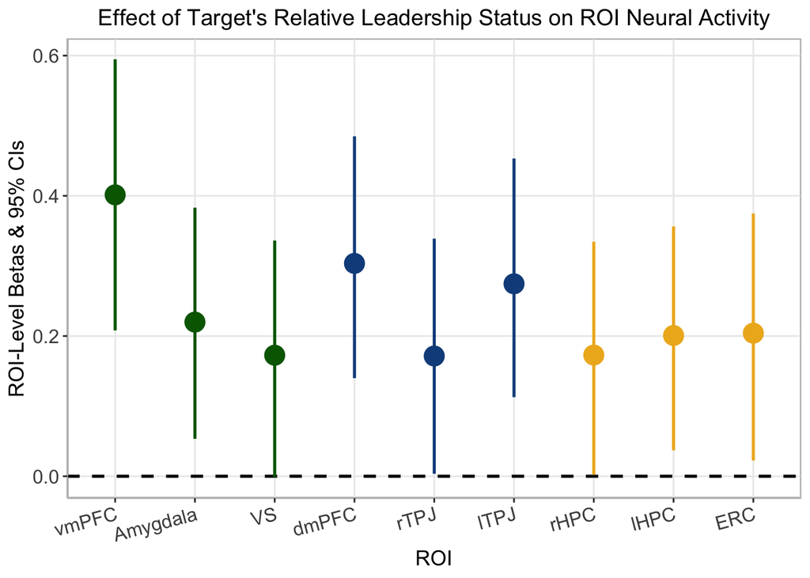

```r
# Load model results
load(sprintf("%s/Model Results/Univariate_Model3.RData", path))

# Extract posterior draws
roi_draws <- m3 %>%
  spread_draws(b_face_leader_strength_in_cw,
               `r_brain_system:roi`[roi, term]) %>%
  filter(term == "face_leader_strength_in_cw") %>%
  mutate(beta = b_face_leader_strength_in_cw + `r_brain_system:roi`) %>%
  mutate(roi = dplyr::recode(roi,
                             "social_cognition_Saxe_dmPFC" = "dmPFC",
                             "valuation_HO_amygdala" = "Amygdala",
                             "relational_binding_r_HPC" = "rHPC",
                             "social_cognition_r_TPJ" = "rTPJ",
                             "valuation_Kable_VS" = "VS",
                             "relational_binding_ERC" = "ERC",
                             "relational_binding_l_HPC" = "lHPC",
                             "social_cognition_l_TPJ" = "lTPJ",
                             "valuation_vmPFC" = "vmPFC"),
         roi = factor(roi, levels = c("vmPFC", "Amygdala", "VS",
                                          "dmPFC", "rTPJ", "lTPJ",
                                          "rHPC", "lHPC", "ERC")),
         roi_type = ifelse(roi %in% c("vmPFC", "Amygdala", "VS"), "valuation",
                        ifelse(roi %in% c("dmPFC", "rTPJ", "lTPJ"), "social_cognition",
                               "relational_binding"))) %>%
  select(.draw, roi, roi_type, beta)

# Summarize estimates per ROI
b_df_leader <- roi_draws %>%
  group_by(roi, roi_type, term) %>%
  summarise(beta_leader = median(beta),
            sd = sd(beta),
            low_ci = quantile(beta, 0.025),
            upp_ci = quantile(beta, 0.975))

# Plot betas' posterior means and 95% credible intervals
ggplot(data = b_df_leader,
       aes(x = roi,
           y = beta_leader)) +
  geom_hline(yintercept = 0,
             linewidth = 0.9, linetype = 2) +
  geom_pointrange(aes(ymin = low_ci,
                      ymax = upp_ci, color = roi_type),
                  size = 1.2, linewidth = .9) +
  scale_color_manual(values = c("goldenrod2", "dodgerblue4", "darkgreen")) +
  labs(x = "ROI", y = "ROI-Level Betas & 95% CIs",
       title = "Effect of Target's Relative Leadership Status on ROI Neural Activity")
```

Check results.

```r
# Arrange data
b_df_table <- b_df_leader %>%
  ungroup() %>%
  mutate(across(where(is.numeric), ~ round(.x, 2)),
         CI_95 = paste0("[", round(low_ci, 2), ", ", round(upp_ci, 2), "]")) %>%
  select(-any_of(c("low_ci", "upp_ci", "roi_type", "term"))) %>%
  arrange(roi)

# Create table of results
b_df_table <- flextable(b_df_table) %>%
  set_header_labels(roi = "ROI",
    beta_leader = "Beta Estimate",
    sd = "SE",
    CI_95 = "95% CI") %>%
  autofit() %>%
  theme_booktabs()

# Save to Word document
doc <- read_docx() %>%
  body_add_par("Table: Univariate Results: Effect of Target's Relative Leadership Status on ROI Neural Activity",
               style = "heading 2") %>%
  body_add_flextable(b_df_table)

print(doc, target = sprintf("%s/Tables/TableS12_Univariate_Model3_Leadership_Betas.docx", path))

b_df_table
```

| ROI | Beta Estimate | SE | 95% CI |
| --- | --- | --- | --- |
| vmPFC | 0.40 | 0.10 | [0.21, 0.59] |
| Amygdala | 0.22 | 0.09 | [0.05, 0.38] |
| VS | 0.17 | 0.09 | [0, 0.34] |
| dmPFC | 0.30 | 0.09 | [0.14, 0.48] |
| rTPJ | 0.17 | 0.09 | [0, 0.34] |
| lTPJ | 0.27 | 0.09 | [0.11, 0.45] |
| rHPC | 0.17 | 0.09 | [0, 0.33] |
| lHPC | 0.20 | 0.08 | [0.04, 0.36] |
| ERC | 0.20 | 0.09 | [0.02, 0.37] |

What percentage of the distribution is higher than zero for different ROI main effects?

```r
# vmPFC
round(length(which(roi_draws$beta[roi_draws$roi == "vmPFC"]>0))/4000*100,1)
```

```
## [1] 100
```

```r
# bilateral amygdala
round(length(which(roi_draws$beta[roi_draws$roi == "Amygdala"]>0))/4000*100,1)
```

```
## [1] 99.4
```

```r
# VS
round(length(which(roi_draws$beta[roi_draws$roi == "VS"]>0))/4000*100,1)
```

```
## [1] 97.4
```

```r
# dmPFC
round(length(which(roi_draws$beta[roi_draws$roi == "dmPFC"]>0))/4000*100,1)
```

```
## [1] 100
```

```r
# rTPJ
round(length(which(roi_draws$beta[roi_draws$roi == "rTPJ"]>0))/4000*100,1)
```

```
## [1] 97.8
```

```r
# lTPJ
round(length(which(roi_draws$beta[roi_draws$roi == "lTPJ"]>0))/4000*100,1)
```

```
## [1] 99.9
```

```r
# rHPC
round(length(which(roi_draws$beta[roi_draws$roi == "rHPC"]>0))/4000*100,1)
```

```
## [1] 97.7
```

```r
# lHPC
round(length(which(roi_draws$beta[roi_draws$roi == "lHPC"]>0))/4000*100,1)
```

```
## [1] 99.1
```

```r
# ERC
round(length(which(roi_draws$beta[roi_draws$roi == "ERC"]>0))/4000*100,1)
```

```
## [1] 98.7
```

Check convergence (R-hat, bulk & tail ESS).

```r
summary(m2)
```

```
##  Family: gaussian
##   Links: mu = identity; sigma = identity
## Formula: neural_response ~ face_like_strength_in_cw + pid_like_strength_in_cw + (1 | groupID:pid) + (1 | groupID:face) + (face_like_strength_in_cw | brain_system:roi)
##    Data: d (Number of observations: 19822)
##   Draws: 4 chains, each with iter = 2000; warmup = 1000; thin = 1;
##          total post-warmup draws = 4000
##
## Group-Level Effects:
## ~brain_system:roi (Number of levels: 9)
##                                         Estimate Est.Error l-95% CI u-95% CI
## sd(Intercept)                               0.83      0.25     0.49     1.46
## sd(face_like_strength_in_cw)                0.07      0.05     0.00     0.19
## cor(Intercept,face_like_strength_in_cw)     0.30      0.50    -0.81     0.97
##                                         Rhat Bulk_ESS Tail_ESS
## sd(Intercept)                           1.00     1009     1863
## sd(face_like_strength_in_cw)            1.00     1523     1788
## cor(Intercept,face_like_strength_in_cw) 1.00     4047     2527
##
## ~groupID:face (Number of levels: 233)
##               Estimate Est.Error l-95% CI u-95% CI Rhat Bulk_ESS Tail_ESS
## sd(Intercept)     0.78      0.05     0.68     0.89 1.00     1273     2195
##
## ~groupID:pid (Number of levels: 94)
##               Estimate Est.Error l-95% CI u-95% CI Rhat Bulk_ESS Tail_ESS
## sd(Intercept)     0.73      0.06     0.62     0.86 1.00      865     1982
##
## Population-Level Effects:
##                          Estimate Est.Error l-95% CI u-95% CI Rhat Bulk_ESS
## Intercept                    0.72      0.29     0.14     1.32 1.00      690
## face_like_strength_in_cw     0.21      0.08     0.06     0.36 1.00     1255
## pid_like_strength_in_cw      0.11      0.12    -0.13     0.36 1.01      697
##                          Tail_ESS
## Intercept                    1149
## face_like_strength_in_cw     1966
## pid_like_strength_in_cw      1411
##
## Family Specific Parameters:
##       Estimate Est.Error l-95% CI u-95% CI Rhat Bulk_ESS Tail_ESS
## sigma     3.46      0.02     3.43     3.50 1.00     8476     3237
##
## Draws were sampled using sampling(NUTS). For each parameter, Bulk_ESS
## and Tail_ESS are effective sample size measures, and Rhat is the potential
## scale reduction factor on split chains (at convergence, Rhat = 1).
```

```r
draws <- as_draws_df(m2)
summarise_draws(draws, rhat, "ess_bulk", "ess_tail") %>%
  filter(grepl("brain_system:roi", variable)) %>%
  mutate(across(where(is.numeric), ~ round(.x, 4)))
```

| variable | rhat | ess_bulk | ess_tail |
| --- | --- | --- | --- |
| sd_brain_system:roi__Intercept | 1.0034 | 1009.0147 | 1862.817 |
| sd_brain_system:roi__face_like_strength_in_cw | 1.0022 | 1523.1473 | 1787.872 |
| cor_brain_system:roi__Intercept__face_like_strength_in_cw | 1.0031 | 4047.4253 | 2527.178 |
| r_brain_system:roi[relational_binding_ERC,Intercept] | 1.0004 | 739.7397 | 1192.124 |
| r_brain_system:roi[relational_binding_l_HPC,Intercept] | 1.0008 | 723.8196 | 1084.025 |
| r_brain_system:roi[relational_binding_r_HPC,Intercept] | 1.0008 | 717.6847 | 1193.682 |
| r_brain_system:roi[social_cognition_l_TPJ,Intercept] | 1.0004 | 719.9346 | 1125.263 |
| r_brain_system:roi[social_cognition_r_TPJ,Intercept] | 1.0008 | 720.9828 | 1227.903 |
| r_brain_system:roi[social_cognition_Saxe_dmPFC,Intercept] | 1.0004 | 732.4680 | 1152.773 |
| r_brain_system:roi[valuation_HO_amygdala,Intercept] | 1.0004 | 712.8743 | 1145.824 |

[output cut: 11 more lines]

# 4 Plot of Model Results Together

Combine all slopes in one file so that we can visualize them together.

```r
b_df <- b_df %>%
  dplyr::rename(beta = beta_2d)
b_df$model <- "Relative Dual Status"
b_df_like <- b_df_like %>%
  dplyr::rename(beta = beta_like)
b_df_like$model <- "Relative Popularity Status"
b_df_leader<- b_df_leader%>%
  dplyr::rename(beta = beta_leader)
b_df_leader$model <- "Relative Leadership Status"
d2 <- rbind(b_df, b_df_like)
d3 <- rbind(d2, b_df_leader)
roi_order <- c("vmPFC", "Amygdala", "VS", "dmPFC",
               "rTPJ", "lTPJ", "rHPC", "lHPC", "ERC")
d3$roi <- factor(d3$roi, levels = rev(roi_order))
model_order <- c("Relative Popularity Status",
                 "Relative Leadership Status",
                 "Relative Dual Status")
d3$model <- factor(d3$model, levels = model_order)
```

Create a plot showing the effect of different types of target relative status (popularity, leadership, dual) on the perceiver’s neural responses in the 9 ROIs. This plot shows the ROI-level effects extracted from the 3 models together.

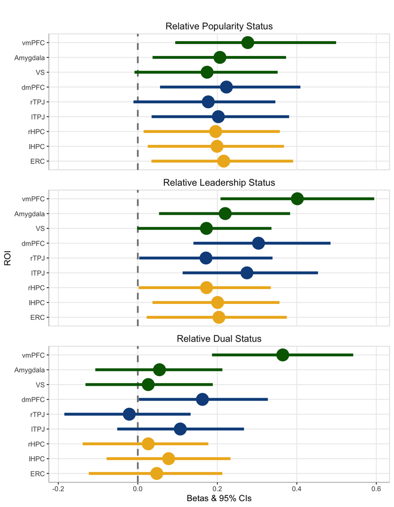

```r
ggplot(data = d3, aes(x = roi, y = beta)) +
  facet_wrap(~model, ncol = 1) +
  geom_hline(yintercept = 0, linewidth = 1,
             linetype = "dashed", color = "gray50") +
  geom_pointrange(aes(ymin = low_ci, ymax = upp_ci,
                      color = roi_type),
    size = 1.6, linewidth = 1.7) +
  scale_color_manual(values = c("goldenrod2",
                                "dodgerblue4", "darkgreen")) +
  labs(x = "ROI",
    y = "Betas & 95% CIs",
    title = "") +
  coord_flip() +
  theme_bw() +
  theme(
    axis.line = element_line(colour = "gray"),
    panel.border = element_blank(),
    panel.grid.minor = element_blank(),
    panel.background = element_rect(colour = "gray80", linewidth = .5),
    legend.position = "none",
    strip.background = element_blank(),
    strip.text = element_text(size = 12))
```